# coursera

```python
import pandas
```

```python
train = pandas.read_csv('./features.csv', index_col='match_id')
test = pandas.read_csv('./features_test.csv', index_col='match_id')
```

```python
# Удаляем признаки, связанные с итогами матча
train.drop(['duration',
         'tower_status_radiant',
         'tower_status_dire',
         'barracks_status_radiant',
         'barracks_status_dire'
        ], axis=1, inplace=True)

train.head(3)
```

| match_id | start_time | lobby_type | r1_hero | r1_level | r1_xp | r1_gold | r1_lh | r1_kills | r1_deaths | r1_items | r2_hero | r2_level | r2_xp | r2_gold | r2_lh | r2_kills | r2_deaths | r2_items | r3_hero | r3_level | r3_xp | r3_gold | r3_lh | r3_kills | r3_deaths | r3_items | r4_hero | r4_level | r4_xp | … |
| --- | --- | --- | --- | --- | --- | --- | --- | --- | --- | --- | --- | --- | --- | --- | --- | --- | --- | --- | --- | --- | --- | --- | --- | --- | --- | --- | --- | --- | --- | --- |
| 0 | 1430198770 | 7 | 11 | 5 | 2098 | 1489 | 20 | 0 | 0 | 7 | 67 | 3 | 842 | 991 | 10 | 0 | 0 | 4 | 29 | 5 | 1909 | 1143 | 10 | 0 | 0 | 8 | 20 | 3 | 757 | … |
| 1 | 1430220345 | 0 | 42 | 4 | 1188 | 1033 | 9 | 0 | 1 | 12 | 49 | 4 | 1596 | 993 | 10 | 0 | 1 | 7 | 67 | 4 | 1506 | 1502 | 18 | 1 | 0 | 7 | 37 | 3 | 669 | … |
| 2 | 1430227081 | 7 | 33 | 4 | 1319 | 1270 | 22 | 0 | 0 | 12 | 98 | 3 | 1314 | 775 | 6 | 0 | 0 | 6 | 20 | 3 | 1297 | 909 | 0 | 1 | 0 | 6 | 27 | 5 | 2360 | … |

### Подход 1: градиентный бустинг "в лоб"

##### Что указать в отчете

В отчете по данному этапу вы должны ответить на следующие вопросы:

1. Какие признаки имеют пропуски среди своих значений? Что могут означать пропуски в этих признаках (ответьте на этот вопрос для двух любых признаков)?
2. Как называется столбец, содержащий целевую переменную?
3. Как долго проводилась кросс-валидация для градиентного бустинга с 30 деревьями? Инструкцию по измерению времени можно найти ниже по тексту. Какое качество при этом получилось? Напомним, что в данном задании мы используем метрику качества AUC-ROC.
4. Имеет ли смысл использовать больше 30 деревьев в градиентном бустинге? Что бы вы предложили делать, чтобы ускорить его обучение при увеличении количества деревьев?

Признаки с пропусками:

```python
rowsNumber = len(features)
numberOfEachFeature = desc.T['count']
numberOfEachFeature[numberOfEachFeature < rowsNumber].sort_values().apply(lambda x: (rowsNumber - x) / rowsNumber)
```

```
first_blood_player2            0.452402
radiant_flying_courier_time    0.282619
dire_flying_courier_time       0.268415
first_blood_time               0.201100
first_blood_team               0.201100
first_blood_player1            0.201100
dire_bottle_time               0.166029
radiant_bottle_time            0.161380
radiant_first_ward_time        0.018883
dire_first_ward_time           0.018780
radiant_courier_time           0.007117
dire_courier_time              0.006953
Name: count, dtype: float64
```

```python
train = train.fillna(0)
# Выделяем целевую переменную и удаляем пропуски
X = train
y = train['radiant_win'].to_frame()
del X['radiant_win']
```

```python
train.head(2)
```

| match_id | start_time | lobby_type | r1_hero | r1_level | r1_xp | r1_gold | r1_lh | r1_kills | r1_deaths | r1_items | r2_hero | r2_level | r2_xp | r2_gold | r2_lh | r2_kills | r2_deaths | r2_items | r3_hero | r3_level | r3_xp | r3_gold | r3_lh | r3_kills | r3_deaths | r3_items | r4_hero | r4_level | r4_xp | … |
| --- | --- | --- | --- | --- | --- | --- | --- | --- | --- | --- | --- | --- | --- | --- | --- | --- | --- | --- | --- | --- | --- | --- | --- | --- | --- | --- | --- | --- | --- | --- |
| 0 | 1430198770 | 7 | 11 | 5 | 2098 | 1489 | 20 | 0 | 0 | 7 | 67 | 3 | 842 | 991 | 10 | 0 | 0 | 4 | 29 | 5 | 1909 | 1143 | 10 | 0 | 0 | 8 | 20 | 3 | 757 | … |
| 1 | 1430220345 | 0 | 42 | 4 | 1188 | 1033 | 9 | 0 | 1 | 12 | 49 | 4 | 1596 | 993 | 10 | 0 | 1 | 7 | 67 | 4 | 1506 | 1502 | 18 | 1 | 0 | 7 | 37 | 3 | 669 | … |

```python
X.head(2)
```

| match_id | start_time | lobby_type | r1_hero | r1_level | r1_xp | r1_gold | r1_lh | r1_kills | r1_deaths | r1_items | r2_hero | r2_level | r2_xp | r2_gold | r2_lh | r2_kills | r2_deaths | r2_items | r3_hero | r3_level | r3_xp | r3_gold | r3_lh | r3_kills | r3_deaths | r3_items | r4_hero | r4_level | r4_xp | … |
| --- | --- | --- | --- | --- | --- | --- | --- | --- | --- | --- | --- | --- | --- | --- | --- | --- | --- | --- | --- | --- | --- | --- | --- | --- | --- | --- | --- | --- | --- | --- |
| 0 | 1430198770 | 7 | 11 | 5 | 2098 | 1489 | 20 | 0 | 0 | 7 | 67 | 3 | 842 | 991 | 10 | 0 | 0 | 4 | 29 | 5 | 1909 | 1143 | 10 | 0 | 0 | 8 | 20 | 3 | 757 | … |
| 1 | 1430220345 | 0 | 42 | 4 | 1188 | 1033 | 9 | 0 | 1 | 12 | 49 | 4 | 1596 | 993 | 10 | 0 | 1 | 7 | 67 | 4 | 1506 | 1502 | 18 | 1 | 0 | 7 | 37 | 3 | 669 | … |

```python
y.head(2)
```

| match_id | radiant_win |
| --- | --- |
| 0 | 1 |
| 1 | 1 |

```python
import numpy as np
import time
import datetime
import matplotlib.pyplot as plt
from sklearn.cross_validation import KFold, cross_val_score, train_test_split
from sklearn.ensemble import GradientBoostingClassifier
from sklearn.metrics import roc_auc_score

kf = KFold(y.size, n_folds=5, shuffle=True, random_state=42)

scores = []
model = GradientBoostingClassifier(n_estimators=30, random_state=42)
start_time = datetime.datetime.now()
model_scores = cross_val_score(model, X, y, cv=kf, scoring='roc_auc', n_jobs=-1)
print ('Кросс-валидация для градиентного бустинга с 30 деревьями заняла ', datetime.datetime.now() - start_time)
print (model_scores)
scores.append(np.mean(model_scores))
```

```
Кросс-валидация для градиентного бустинга с 30 деревьями заняла  0:00:40.422589
[ 0.68892093  0.68934663  0.68712298  0.69180598  0.69283583]
```

4. Имеет ли смысл использовать больше 30 деревьев в градиентном бустинге? Что бы вы предложили делать, чтобы ускорить его обучение при увеличении количества деревьев?

```python
scores = []
nums = [10, 20, 30, 50, 100, 200]
for n in nums:
    print ('#', str(n))
    model = GradientBoostingClassifier(n_estimators=n, random_state=42)
    start_time = datetime.datetime.now()
    model_scores = cross_val_score(model, X, y, cv=kf, scoring='roc_auc', n_jobs=-1)
    print ('Time elapsed:', datetime.datetime.now() - start_time)
    print (model_scores)
    scores.append(np.mean(model_scores))
```

```
# 10
Time elapsed: 0:00:15.906686
[ 0.66383799  0.66635457  0.66360048  0.66529818  0.66516222]
# 20
Time elapsed: 0:00:27.658482
[ 0.68083889  0.68272733  0.67969876  0.6834932   0.6855512 ]
# 30
Time elapsed: 0:00:42.376315
[ 0.68892093  0.68934663  0.68712298  0.69180598  0.69283583]
# 50
Time elapsed: 0:01:07.469576
[ 0.69627399  0.69747879  0.69470891  0.69921915  0.69979097]
# 100
Time elapsed: 0:02:10.712383
[ 0.70515496  0.706077    0.70429951  0.7074682   0.70811523]
# 200
Time elapsed: 0:04:24.168958
[ 0.71214175  0.71304181  0.71259725  0.71556107  0.71510233]
```

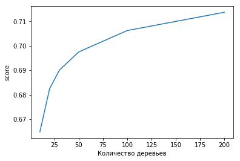

```python
plt.plot(nums, scores)
plt.xlabel('Количество деревьев')
plt.ylabel('score')
plt.show()
```

Видно, что при использовании более 30 деревьев качество возрастает. Для ускорения обучения можно использовать не всю выборку и снизить высоту деревьев.

### Подход 2: логистическая регрессия

##### Что указать в отчете

В отчете по данному этапу вы должны ответить на следующие вопросы:

1. Какое качество получилось у логистической регрессии над всеми исходными признаками? Как оно соотносится с качеством градиентного бустинга? Чем вы можете объяснить эту разницу? Быстрее ли работает логистическая регрессия по сравнению с градиентным бустингом?
2. Как влияет на качество логистической регрессии удаление категориальных признаков (укажите новое значение метрики качества)? Чем вы можете объяснить это изменение?
3. Сколько различных идентификаторов героев существует в данной игре?
4. Какое получилось качество при добавлении "мешка слов" по героям? Улучшилось ли оно по сравнению с предыдущим вариантом? Чем вы можете это объяснить?
5. Какое минимальное и максимальное значение прогноза на тестовой выборке получилось у лучшего из алгоритмов?

```python
from sklearn.linear_model import LogisticRegression
from sklearn.preprocessing import StandardScaler

def optimize_C(X, y):

    kf = KFold(y.size, n_folds=5, shuffle=True, random_state=42)

    scores = []
    C_pow_range = range(-6, 1)
    C_range = [10.0 ** i for i in C_pow_range]
    for C in C_range:
        start_time = datetime.datetime.now()

        print ('C =', str(C))
        model = LogisticRegression(C=C, random_state=42, n_jobs=-1)
        model_scores = cross_val_score(model, X, y, cv=kf, scoring='roc_auc', n_jobs=-1)
        print (model_scores)

        print ('Time elapsed:', datetime.datetime.now() - start_time)
        scores.append(np.mean(model_scores))

    max_score = max(scores)
    max_score_index = scores.index(max_score)
    return C_pow_range, C_range, scores, max_score, max_score_index
```

```python
scaler = StandardScaler()
X = scaler.fit_transform(X)
C_pow_range, C_range, scores, max_score, max_score_index = optimize_C(X,y)
```

[output not shown]

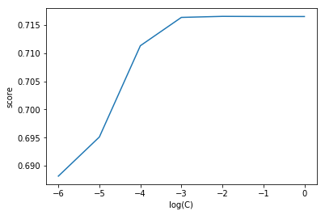

```python
plt.plot(C_pow_range, scores)
plt.xlabel('log(C)')
plt.ylabel('score')
plt.show()
```

```python
C = C_range[max_score_index]
score = max_score
print ("Выбранное значение параметра регуляризации:",C)
print ("Качество при C =",C, ":", score)
```

```
Выбранное значение параметра регуляризации: 0.01
Качество при C = 0.01 : 0.716559388563
```

Логистическая регрессия значительно быстрее, такие результаты достигаются при использовании аш 200 деревьев.

```python
train = pandas.read_csv('./features.csv', index_col='match_id')
train = train.fillna(0)

# Удаляем признаки, связанные с итогами матча
train.drop(['duration',
         'tower_status_radiant',
         'tower_status_dire',
         'barracks_status_radiant',
         'barracks_status_dire'
        ], axis=1, inplace=True)

#Удалим категориальные признаки

del train['lobby_type']
for n in range(1, 6):
    del train['r{}_hero'.format(n)]
    del train['d{}_hero'.format(n)]

X = train
y = train['radiant_win'].to_frame()
del X['radiant_win']
```

```python
scaler = StandardScaler()
X = scaler.fit_transform(X)
C_pow_range, C_range, scores, max_score, max_score_index = optimize_C(X,y)
```

[output not shown]

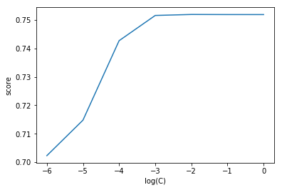

```python
plt.plot(C_pow_range, scores)
plt.xlabel('log(C)')
plt.ylabel('score')
plt.show()
```

```python
C = C_range[max_score_index]
score = max_score
print ("Выбранное значение параметра регуляризации:",C)
print ("Качество при C =",C, ":", score)
```

```
Выбранное значение параметра регуляризации: 0.01
Качество при C = 0.01 : 0.751964043162
```

```python
heroes = pandas.read_csv('./data/dictionaries/heroes.csv')
print ("В игре", len(heroes), "героев.")
def hero_bag(X):
    X_pick = np.zeros((X.shape[0], len(heroes)))
    for i, match_id in enumerate(X.index):
        for p in range(5):
            X_pick[i, X.ix[match_id, 'r%d_hero' % (p+1)]-1] = 1
            X_pick[i, X.ix[match_id, 'd%d_hero' % (p+1)]-1] = -1

    return pandas.DataFrame(X_pick, index=X.index)

train = pandas.read_csv('./features.csv', index_col='match_id')
train = train.fillna(0)

# Удаляем признаки, связанные с итогами матча
train.drop(['duration',
         'tower_status_radiant',
         'tower_status_dire',
         'barracks_status_radiant',
         'barracks_status_dire'
        ], axis=1, inplace=True)


X_hero_bag = hero_bag(train)
for n in range(1, 6):
    del train['r{}_hero'.format(n)]
    del train['d{}_hero'.format(n)]
del train['radiant_win']
X = train

X = pandas.DataFrame(scaler.fit_transform(X), index = X.index)
X = pandas.concat([X, X_hero_bag], axis=1)
```

```
В игре 112 героев.
```

```python
C_pow_range, C_range, scores, max_score, max_score_index = optimize_C(X,y)
```

```
C = 1e-06
[ 0.68840386  0.69052047  0.69108255  0.69040564  0.6924301 ]
Time elapsed: 0:00:06.058587
C = 1e-05
[ 0.69719003  0.69885588  0.69963948  0.69929162  0.70117211]
Time elapsed: 0:00:06.139462
C = 0.0001
[ 0.72356318  0.72410258  0.72472923  0.72592908  0.72700417]
Time elapsed: 0:00:07.813712
C = 0.001
[ 0.74461244  0.74667537  0.7441472   0.74876927  0.74741013]
Time elapsed: 0:00:10.531161
C = 0.01
[ 0.74943163  0.75279     0.74925501  0.75536514  0.75178663]
Time elapsed: 0:00:15.081937
C = 0.1
[ 0.74939526  0.75315718  0.74951205  0.75596615  0.7516599 ]
Time elapsed: 0:00:19.874282
C = 1.0
[ 0.74932405  0.75317203  0.74950065  0.75600271  0.75158891]
Time elapsed: 0:00:21.392295
```

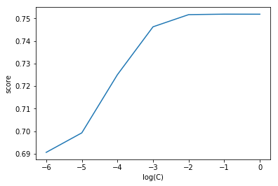

```python
plt.plot(C_pow_range, scores)
plt.xlabel('log(C)')
plt.ylabel('score')
plt.show()
```

```python
C = C_range[max_score_index]
score = max_score
print ("Выбранное значение параметра регуляризации:",C)
print ("Качество при C =",C, ":", score)
```

```
Выбранное значение параметра регуляризации: 0.1
Качество при C = 0.1 : 0.751938109315
```